# The G173-03 reference solar spectra

Taha Ahmed

2023-07-12

As our energy system must urgently transition to a larger dependence on solar energy, I thought it could be worthwhile to walk through the physical limits imposed by the terrestrial solar spectrum.

We start with the reference solar spectrum ASTM G173-03, as defined by ASTM and published by NREL, which is included as `ASTMG173` in this package:

```r
dataset <- photoec::ASTMG173
dataset %>% glimpse()
```

```
## Rows: 2,002
## Columns: 4
## $ wavelength         <dbl> 280.0, 280.5, 281.0, 281.5, 282.0, 282.5, 283.0, 283.5,…
## $ extraterrestrial   <dbl> 0.08200, 0.09900, 0.15000, 0.21200, 0.26700, 0.30300, 0…
## $ globaltilt         <dbl> 4.7309e-23, 1.2307e-21, 5.6895e-21, 1.5662e-19, 1.1946e…
## $ direct.circumsolar <dbl> 2.5361e-26, 1.0917e-24, 6.1253e-24, 2.7479e-22, 2.8346e…
```

This dataframe is in wide format. We can convert it to tidy (long) format for easier plotting with ggplot2:

```r
# while we are at it, let's give the existing columns more descriptive names
dataset <- dataset %>%
   rename(AM0 = extraterrestrial) %>%
   rename(AM1.5G = globaltilt) %>%
   # direct normal circumsolar
   rename(DNCS = direct.circumsolar)
datalong <- dataset %>% pivot_longer(
   cols = !starts_with("wavelength"),
   names_to = "model",
   values_to = "value") %>%
   mutate(property = "spectralirradiance")
datalong %>% glimpse()
```

```
## Rows: 6,006
## Columns: 4
## $ wavelength <dbl> 280.0, 280.0, 280.0, 280.5, 280.5, 280.5, 281.0, 281.0, 281.0, …
## $ model      <chr> "AM0", "AM1.5G", "DNCS", "AM0", "AM1.5G", "DNCS", "AM0", "AM1.5…
## $ value      <dbl> 8.2000e-02, 4.7309e-23, 2.5361e-26, 9.9000e-02, 1.2307e-21, 1.0…
## $ property   <chr> "spectralirradiance", "spectralirradiance", "spectralirradiance…
```

And take a first look at the G137-03 reference solar spectra as included in this dataset `photoec::ASTMG173`:

[figure not shown]

Now, as a sanity check, let’s compare the spectra returned by this package’s `sunlight.ASTM()` function with those above (should be an exact match if you use the same wavelength vector).

[figure not shown]

They look the same, and indeed, the values (here exemplified by AM1.5G) returned by the dataset and the function are pairwise equal:

```r
dplyr::near(
   datalong %>% filter(model == "AM1.5G") %>% filter(property == "spectralirradiance") %>% pull(value),
   dflong %>% filter(model == "AM1.5G") %>% filter(property == "spectralirradiance") %>% pull(value)) %>% all()
```

```
## [1] TRUE
```

Whereas the dataset contains **only spectral irradiance**, the dataframe returned by the `photoec::sunlight.ASTM()` function **includes other derived properties**, namely, absolute and relative cumulative irradiance (`irradiance` and `irradiance.fraction`), spectral photon flux (`spectralphotonflux`) and absolute and relative cumulative photon flux (`photonflux` and `photonflux.fraction`).

This allows us to easily explore not only spectral irradiance but also irradiance (radiant power in kW m⁻²) and the distribution of cumulative radiant power by wavelength. And in the same way, it allows us to explore spectral photon flux, photon flux, and cumulative photon flux by wavelength:

[figure not shown]

Quantities returned by the `sunlight.ASTM()` function for the AM0, AM1.5G and DNCS spectra: **(a)** Solar spectral irradiance, **(b)** cumulative irradiance, **(c)** irradiance fraction, **(d)** spectral photon flux, **(e)** cumulative photon flux, and **(f)** photon flux fraction.

About 75% of the total irradiance (i.e., power) is contained below 1000 nm, but only about 50% of the total photon flux. This makes sense, since each lower-wavelength photon carries more energy.

Spectral irradiance AM1.5G and derived properties

In the visible range and showing only every 10th nm

| *λ*/nm | *E*/eV | *I*<sub>λ</sub>/W m⁻² nm⁻¹ | *I*/W m⁻² | *I* / *I*<sub>max</sub> | *Φ*<sub>λ</sub>/s⁻¹ m⁻² nm⁻¹ | *Φ*/s⁻¹ m⁻² | *Φ* / *Φ*<sub>max</sub> | *j*/mA cm⁻² | STH/% |
| --- | --- | --- | --- | --- | --- | --- | --- | --- | --- |
| 380 | 3.26 | 0.7008 | 32.26 | 0.0322 | 1.34 × 10<sup>18</sup> | 5.72 × 10<sup>19</sup> | 0.0133 | 9.168 | 1.13 |
| 390 | 3.18 | 0.7970 | 38.59 | 0.0386 | 1.56 × 10<sup>18</sup> | 6.95 × 10<sup>19</sup> | 0.0161 | 11.13 | 1.37 |
| 400 | 3.10 | 1.114 | 46.10 | 0.0461 | 2.24 × 10<sup>18</sup> | 8.44 × 10<sup>19</sup> | 0.0196 | 13.53 | 1.66 |
| 410 | 3.02 | 1.048 | 57.65 | 0.0576 | 2.16 × 10<sup>18</sup> | 1.08 × 10<sup>20</sup> | 0.0251 | 17.30 | 2.13 |
| 420 | 2.95 | 1.123 | 69.66 | 0.0696 | 2.37 × 10<sup>18</sup> | 1.33 × 10<sup>20</sup> | 0.0309 | 21.32 | 2.62 |
| 430 | 2.88 | 0.8746 | 81.54 | 0.0815 | 1.89 × 10<sup>18</sup> | 1.58 × 10<sup>20</sup> | 0.0368 | 25.39 | 3.12 |
| 440 | 2.82 | 1.350 | 93.54 | 0.0935 | 2.99 × 10<sup>18</sup> | 1.85 × 10<sup>20</sup> | 0.0429 | 29.60 | 3.64 |
| 450 | 2.76 | 1.560 | 107.9 | 0.108 | 3.53 × 10<sup>18</sup> | 2.17 × 10<sup>20</sup> | 0.0504 | 34.75 | 4.27 |
| 460 | 2.70 | 1.529 | 123.3 | 0.123 | 3.54 × 10<sup>18</sup> | 2.52 × 10<sup>20</sup> | 0.0586 | 40.42 | 4.97 |
| 470 | 2.64 | 1.508 | 138.9 | 0.139 | 3.57 × 10<sup>18</sup> | 2.89 × 10<sup>20</sup> | 0.0671 | 46.26 | 5.69 |
| 480 | 2.58 | 1.618 | 154.7 | 0.155 | 3.91 × 10<sup>18</sup> | 3.27 × 10<sup>20</sup> | 0.0758 | 52.32 | 6.43 |
| 490 | 2.53 | 1.622 | 170.0 | 0.170 | 4.00 × 10<sup>18</sup> | 3.64 × 10<sup>20</sup> | 0.0845 | 58.30 | 7.17 |
| 500 | 2.48 | 1.545 | 185.7 | 0.186 | 3.89 × 10<sup>18</sup> | 4.03 × 10<sup>20</sup> | 0.0936 | 64.56 | 7.94 |
| 510 | 2.43 | 1.548 | 201.1 | 0.201 | 3.97 × 10<sup>18</sup> | 4.42 × 10<sup>20</sup> | 0.103 | 70.84 | 8.71 |
| 520 | 2.38 | 1.524 | 216.0 | 0.216 | 3.99 × 10<sup>18</sup> | 4.81 × 10<sup>20</sup> | 0.112 | 77.03 | 9.47 |
| 530 | 2.34 | 1.545 | 231.3 | 0.231 | 4.12 × 10<sup>18</sup> | 5.21 × 10<sup>20</sup> | 0.121 | 83.51 | 10.3 |
| 540 | 2.30 | 1.482 | 246.8 | 0.247 | 4.03 × 10<sup>18</sup> | 5.63 × 10<sup>20</sup> | 0.131 | 90.19 | 11.1 |
| 550 | 2.25 | 1.540 | 262.1 | 0.262 | 4.26 × 10<sup>18</sup> | 6.05 × 10<sup>20</sup> | 0.140 | 96.91 | 11.9 |
| 560 | 2.21 | 1.474 | 277.3 | 0.277 | 4.16 × 10<sup>18</sup> | 6.48 × 10<sup>20</sup> | 0.150 | 103.7 | 12.8 |
| 570 | 2.18 | 1.482 | 292.4 | 0.292 | 4.25 × 10<sup>18</sup> | 6.90 × 10<sup>20</sup> | 0.160 | 110.6 | 13.6 |
| 580 | 2.14 | 1.502 | 307.3 | 0.307 | 4.39 × 10<sup>18</sup> | 7.33 × 10<sup>20</sup> | 0.170 | 117.5 | 14.4 |
| 590 | 2.10 | 1.371 | 322.2 | 0.322 | 4.07 × 10<sup>18</sup> | 7.77 × 10<sup>20</sup> | 0.181 | 124.5 | 15.3 |
| 600 | 2.07 | 1.475 | 336.7 | 0.337 | 4.46 × 10<sup>18</sup> | 8.21 × 10<sup>20</sup> | 0.191 | 131.5 | 16.2 |
| 610 | 2.03 | 1.469 | 351.4 | 0.351 | 4.51 × 10<sup>18</sup> | 8.66 × 10<sup>20</sup> | 0.201 | 138.7 | 17.1 |
| 620 | 2.00 | 1.474 | 366.0 | 0.366 | 4.60 × 10<sup>18</sup> | 9.11 × 10<sup>20</sup> | 0.212 | 145.9 | 17.9 |
| 630 | 1.97 | 1.392 | 380.2 | 0.380 | 4.42 × 10<sup>18</sup> | 9.55 × 10<sup>20</sup> | 0.222 | 153.1 | 18.8 |
| 640 | 1.94 | 1.434 | 394.5 | 0.394 | 4.62 × 10<sup>18</sup> | 1.00 × 10<sup>21</sup> | 0.233 | 160.4 | 19.7 |
| 650 | 1.91 | 1.359 | 408.7 | 0.409 | 4.45 × 10<sup>18</sup> | 1.05 × 10<sup>21</sup> | 0.243 | 167.8 | 20.6 |
| 660 | 1.88 | 1.399 | 422.3 | 0.422 | 4.65 × 10<sup>18</sup> | 1.09 × 10<sup>21</sup> | 0.254 | 175.0 | 21.5 |
| 670 | 1.85 | 1.420 | 436.4 | 0.436 | 4.79 × 10<sup>18</sup> | 1.14 × 10<sup>21</sup> | 0.265 | 182.5 | 22.4 |
| 680 | 1.82 | 1.397 | 450.4 | 0.450 | 4.78 × 10<sup>18</sup> | 1.19 × 10<sup>21</sup> | 0.276 | 190.2 | 23.4 |
| 690 | 1.80 | 1.182 | 463.2 | 0.463 | 4.11 × 10<sup>18</sup> | 1.23 × 10<sup>21</sup> | 0.286 | 197.2 | 24.2 |
| 700 | 1.77 | 1.282 | 475.9 | 0.476 | 4.52 × 10<sup>18</sup> | 1.28 × 10<sup>21</sup> | 0.296 | 204.4 | 25.1 |
| 710 | 1.75 | 1.318 | 488.9 | 0.489 | 4.71 × 10<sup>18</sup> | 1.32 × 10<sup>21</sup> | 0.307 | 211.7 | 26.0 |
| 720 | 1.72 | 0.9855 | 500.9 | 0.501 | 3.57 × 10<sup>18</sup> | 1.36 × 10<sup>21</sup> | 0.317 | 218.6 | 26.9 |
| 730 | 1.70 | 1.128 | 511.7 | 0.512 | 4.15 × 10<sup>18</sup> | 1.40 × 10<sup>21</sup> | 0.326 | 225.0 | 27.7 |
| 740 | 1.68 | 1.220 | 523.6 | 0.523 | 4.54 × 10<sup>18</sup> | 1.45 × 10<sup>21</sup> | 0.336 | 232.0 | 28.5 |
| 750 | 1.65 | 1.234 | 536.0 | 0.536 | 4.66 × 10<sup>18</sup> | 1.49 × 10<sup>21</sup> | 0.347 | 239.5 | 29.4 |
| 760 | 1.63 | 0.2660 | 547.8 | 0.548 | 1.02 × 10<sup>18</sup> | 1.54 × 10<sup>21</sup> | 0.358 | 246.6 | 30.3 |
| 770 | 1.61 | 1.161 | 555.0 | 0.555 | 4.50 × 10<sup>18</sup> | 1.57 × 10<sup>21</sup> | 0.364 | 251.1 | 30.9 |
| 780 | 1.59 | 1.164 | 566.7 | 0.566 | 4.57 × 10<sup>18</sup> | 1.61 × 10<sup>21</sup> | 0.375 | 258.4 | 31.8 |

Please note that the spectral irradiance and flux shown in the table are not summed over the wavelength interval. That is, they are simply the value *at the shown wavelength*, and not the spectral irradiance/flux summed over the wavelength interval (10 nm in this case). The calculated current density and STH values assume perfect quantum efficiency, Faradaic efficiency and no band gap and are only meant as an illustrative ceiling.

## Geometry of the AM1.5G reference

Let’s consider the the geometry of the global tilt solar reference spectrum (AM1.5G).

At this point I would like to extend my thanks to Zhang Yangdong’s blog for providing one of the few illustrations (outside of the scientific literature) demonstrating all the angles (ha!) involved in the AM1.5G geometry. His blog appears to have been [lost to cyberspace](https://blog.sciencenet.cn/blog-616448-889852.html), but the [illustration itself](http://image.sciencenet.cn/album/201505/13/120558i594h5nz124gfj3c.jpg) is still accessible via the blog’s webhost.

Below is my own sketch of the AM1.5G geometry (absorber is a plane tilted at 37°, with AM1.5 irradiation) created with TikZ (all angles are correct, but lengths are only illustrative):

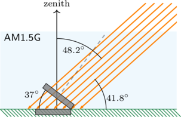

The AM1.5G spectrum of the G173-03 ASTM reference is based on a receiving surface at an inclined plane at a tilt angle of 37° towards the equator and facing the sun at a zenith angle of 48.2° (air mass 1.5), with atmospheric conditions based on the 1976 U.S. Standard Atmosphere.

At air mass 1.5 the zenith angle is 48.2°, and the solar altitude is (the complementary angle) 41.8°. Note how the tilted absorber negates some of the projection effect (in the sketch, the tilted plane absorbs six solar rays, whereas the horizontal plane absorbs only five). That is, of course, the whole point of tilting the absorbing surface at higher altitudes. 37° roughly matches the average latitude of the contiguous United States, and air mass 1.5, as we have seen, corresponds to a latitude of 48° which is representative of the temperate zone wherein many industrialised cities around the world happen to be located.

## Sources

- https://www.nrel.gov/grid/solar-resource/spectra-am1.5.html
- https://en.wikipedia.org/w/index.php?title=Air_mass_(solar_energy)&oldid=1158991725
- https://en.wikipedia.org/w/index.php?title=Geographic_center_of_the_United_States&oldid=1159819200#Contiguous_United_States
- https://www.nrel.gov/grid/solar-resource/spectra-am1.5.html